# Starting density controls final area of activation

### Set up environment

```python
import lateral_signaling as lsig
import numpy as np
import pandas as pd
from tqdm import tqdm
import numba

import scipy.integrate as sint
from scipy.spatial import Voronoi

import holoviews as hv
import colorcet as cc
hv.extension("matplotlib")
```

```python
%load_ext blackcellmagic
```

## Growth processes and bi-phasic induction

We observe that, in some long time-courses, as cell density increases due to cell division, the propagation of fluorescence from a sender cell slows down and can eventually extinguish entirely, resulting in a bi-phasic induction behavior.

Using the regularity assumption, we can capture changes in density using `Model 2a`,

\begin{align} \frac{\mathrm{d}\, \vec{s}}{\mathrm{d} t} &= \lambda + \alpha \frac{\left(\vec{\overline{s}}_{(t-\tau)}\right)^p}{k^p + \left(\delta \vec{s}_{(t-\tau)}\right)^p + \left(\vec{\overline{s}}_{(t-\tau)}\right)^p} - \vec{s} \\[1em] \vec{\overline{s}} &= \frac{\ell A \vec{s}}{P_0}, \end{align}

where $\ell=\frac{r}{\sqrt{3}}$ is the shared contact between any two adjacent cells (edge length of the hexagon).

We represent density with the variable $\rho$ and model changes in density by assuming that cell growth follow the logistic growth equation

\begin{align} \frac{\mathrm{d} \rho}{\mathrm{d} t} &= \xi\,\rho\, \left(1 - \frac{\rho}{\rho_{\text{max}}}\right). \end{align}

where $\rho_\text{max}$ is the maximum density at saturation and $\xi$ is the growth rate of the cell line. We previously non-dimensionalized chemical reaction rates to the signal decay rate [ref]. If we assume that the signal decay rate is equal to the growth rate (i.e. protein degradation contributes negligibly to decay), we can set $\xi=1$. By direct integration,

\begin{align} \rho(t) &= \frac{\rho_\text{max} \rho_0\, e^t}{\rho_\text{max} + \rho_0\,(e^t-1)}. \end{align}

```python
@numba.njit
def rho_t(t, rho_0, rho_max):
    """Returns density at time(s) `t` under logistic assumption."""
    return rho_max * rho_0 * np.exp(t) / (rho_max + rho_0 * (np.exp(t) - 1))
```

#### Estimating density parameters

We define the density $\rho=1$ to be the density at which cells fill the surface area of the culture well with few to no gaps and the culture is ~100% confluent. We had previously estimated this to correspond to a density of ~$1250\; \text{mm}^{-2}$ [ref]. In another growth experiment [ref], we estimated the cell density at saturation to be ~$5000\; \text{mm}^{-2}$, or $\rho_\text{max}\approx4$.

### Comparing maximal area of activation

To understand how the starting density is related to the maximum area at activation, we sample values of $\rho_0$ regularly on the interval $\rho_0 \in [1,\rho_\text{max}]$ and calculate the maximum area of activated cells.

#### Define function(s) for DDE integration

```python
def tc_rhs_2a(S, S_delay, Adj, sender_idx, alpha, k, p, delta, lambda_, ell):
    """
    Right-hand side of the transciever circuit delay
    differential equation. Uses a matrix of cell-cell contact
    lengths `L`.
    """

    # Set perimeter at density = 1
    P0 = 6 / np.sqrt(3)

    # Get input signal across each interface
    S_bar = ell * Adj @ S_delay / P0

    # Calculate dE/dt
    dS_dt = (
        alpha
        * (S_bar ** p)
        / (k ** p + (delta * S_delay) ** p + S_bar ** p)
        - S
    )

    # Set sender cell to zero
    dS_dt[sender_idx] = 0

    return dS_dt


def get_rhs(Adj, sender_idx, func):
    """Given the indices of sender cells, returns a
    function `rhs` with call signature
    rhs(S, S_delay, *args) that can be passed to
    `lsig.integrate_DDE` and `lsig.integrate_DDE_varargs`.
    """

    def rhs(S, S_delay, *args):
        return func(S, S_delay, Adj, sender_idx, *args)

    return rhs
```

```python
# Make square lattice
rows = cols = 20
r = 1.   # cell-cell distance
X, Adj = lsig.hex_Adj(rows, cols, r=r, sparse=True)

# Get # cells
n = X.shape[0]
```

```python
# Set sender cell
sender_idx = lsig.get_center_cells(X)

# Get RHS
rhs = get_rhs(Adj, sender_idx, tc_rhs_2a)
```

We set the time-window long enough to reach stationarity.

```python
# Set time parameters
tmax = 5
nt_t = 100
nt = int(nt_t * tmax) + 1
t = np.linspace(0, tmax, nt)
```

```python
# Set options for rho sampling
rho_min, rho_max = 1, 4
n_rho = 25

# Sample rho
rho_0_space = np.linspace(rho_min, rho_max, n_rho)
```

For the remaining parameters, we use our example parameter set

```python
# Set signaling parameters
alpha = 3
k = 0.12
p = 2
delta = 3
lambda_ = 1e-6

# Set delay
delay = 0.4
```

```python
# Set max density
rho_max = 4

# Step function
# ell_t = np.array([1 / np.sqrt(3 * (rho_0 + (rho_max-rho_0)*(t_>2))) for t_ in t])
```

```python
def A_cells_um(nc, rho, A_c_rho1=800):
    """
    Returns the area of `nc` cells at density `rho` in
    micrometers^2.
    `A_c_rho1` is the area of each cell at a density of 1 in
    micrometers^2.
    """
    return nc * A_c_rho1 / rho
```

```python
# Set initial fluorescence
S0 = np.zeros(n, dtype=np.float32)
S0[sender_idx] = 1

# Initialize results vector
S_rho0_t = np.empty((n_rho, nt, n), dtype=np.float32)
A_rho0_t = np.empty((n_rho, nt), dtype=np.float32)

iterator = range(n_rho)
iterator = tqdm(iterator)
for i in iterator:

    # Get parameters
    rho_0 = rho_0_space[i]
    rho_t_ = rho_t(t, rho_0=rho_0, rho_max=rho_max)
    r_t = 1/np.sqrt(rho_t_)
    ell_t = r_t / np.sqrt(3)

    # Package parameters
    args = (alpha, k, p, delta, lambda_, ell_t[0])

    # Simulate
    S_t = lsig.integrate_DDE_varargs(
        t,
        rhs,
        var_vals=ell_t,
        dde_args=args,
        E0=S0,
        delay=delay,
        where_vars=5,
        min_delay=5,
        progress_bar=False,
    )

    S_rho0_t[i] = S_t
    n_act = (S_t > k).sum(axis=1)
    A_rho0_t[i] = A_cells_um(n_act, rho_t_)
```

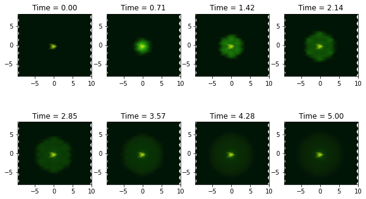

```python
import matplotlib.pyplot as plt
%matplotlib inline

# Set dimensions for a grid of frames
nrows, ncols = 2, 4

# Render frames
nplot = nrows * ncols
idx = [int(i) for i in np.linspace(0, nt-1, nplot)]
fig, axs = plt.subplots(nrows=nrows, ncols=ncols, figsize=(10,6))
for ax, i in zip(axs.flat, idx):
    title=f"Time = {t[i]:.2f}"
    lsig.inspect_colormesh(
        ax=ax,
        X=X,
        rows=rows,
        cols=cols,
        var=S_rho0_t[0],
        idx=i,
        vmin=0,
        vmax=1,
        cmap="kgy",
#         xlim=xlim,
#         ylim=ylim,
        title=title,
    )
```

```python
# Get max activated area for each condition
S_max_area = A_rho0_t.max(axis=1)
```

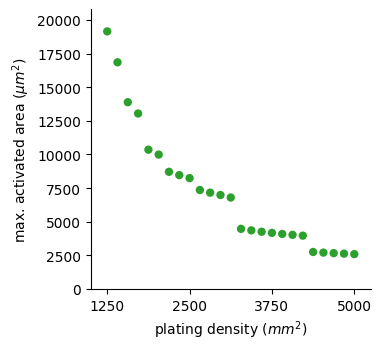

```python
%%capture --no-display

data = {
    "max_area": S_max_area,
    "rho_0": rho_0_space * 1250,
}

p1 = hv.Scatter(
    data=data,
    kdims=["rho_0"],
    vdims=["max_area"],
).opts(
    color=cc.glasbey_category10[2],
    xlabel=r"plating density ($mm^2$)",
    xlim=(1000, 5250),
    xticks=[1250, 2500, 3750, 5000],
    ylabel=r"max. activated area ($\mu m^2$)",
    ylim=(0, None),
)

hv.output(p1, dpi=100)
```

```python
import os
```

## Save plots

```python
# Set filepath and format
fmt = "png"
dirname = "plots"
fname = f"active_area_plot_rhomax_{rho_max:.2f}_rho0_{rho_min:.2f}-{rho_max:.2f}" + "." + fmt

fpath = os.path.join(dirname, fname)
```

```python
%%capture --no-display

hv.save(p1, fpath, fmt=fmt, dpi=150)
```

```python
%load_ext watermark
```

```python
%watermark -v -p numpy,scipy,numba,holoviews,jupyterlab
```

```
CPython 3.7.7
IPython 7.18.1

numpy 1.18.1
scipy 1.4.1
numba 0.51.2
holoviews 1.13.2
jupyterlab 1.2.6
```